# LivDivDataPlotsRD

Siddarth Ravikanti

6/8/2022

#Initial look at Livdiv data set and creating basic vizualizations #Import libraries needed to create plots

```r
inc <-baseline %>% select(contains("inc"))
```

## Number of Children per household

# scatter plot illustrating the number of children vs total household income

# Analyzing to see if there is any correlation between both data points

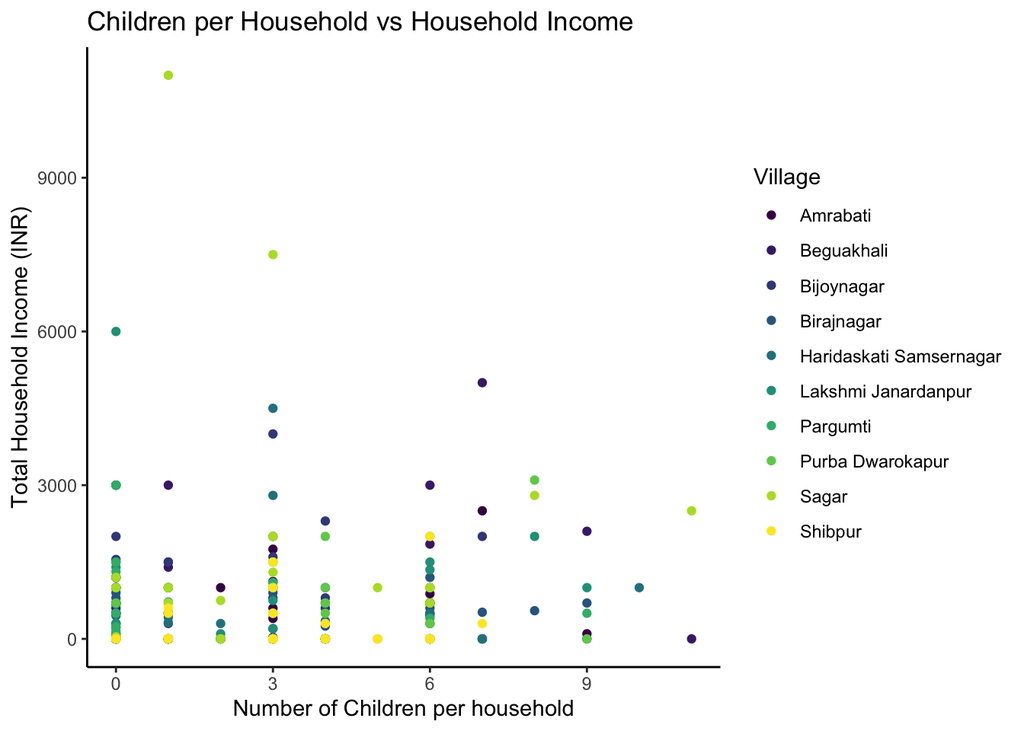

```r
ggplot(baseline, aes(nb_children, inc_total, color = village)) + geom_point() + theme_classic() + labs(x = "Number of Children per household", y = "Total Household Income (INR)", title = "Children per Household vs Household Income", color = "Village") + scale_color_viridis_d()
```

```r
summary(baseline$nb_children)
```

```
##    Min. 1st Qu.  Median    Mean 3rd Qu.    Max.
##    0.00    0.00    2.00    2.52    4.00   11.00
```

number children by household per village total household income per village

*Source - https://www.pewresearch.org/religion/2021/09/21/causes-of-religious-change/

##“Proportion of HH with migrant”

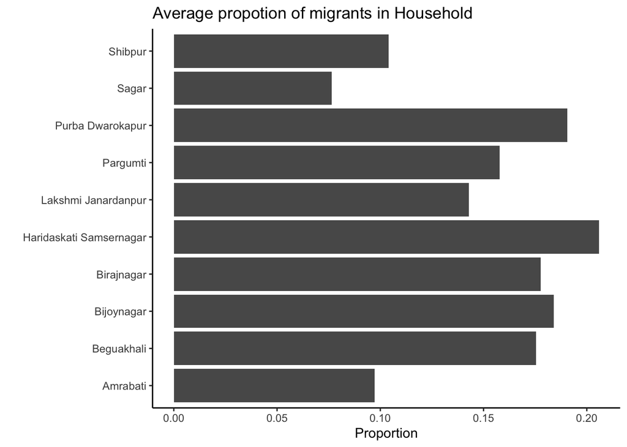

```r
migrant_prop <- baseline %>% group_by(village) %>% summarize(migrant_proportion = mean(hh_migrant_prop))

ggplot(migrant_prop, aes(village, migrant_proportion)) + geom_col() + theme_classic() + labs(x = "", y = "Proportion", title = "Average propotion of migrants in Household") + coord_flip() + scale_fill_viridis_d()
```

```r
summary(migrant_prop$migrant_proportion)
```

```
##    Min. 1st Qu.  Median    Mean 3rd Qu.    Max.
## 0.07653 0.11372 0.16660 0.15118 0.18242 0.20587
```

##“Proportion of HH involved in agriculture”

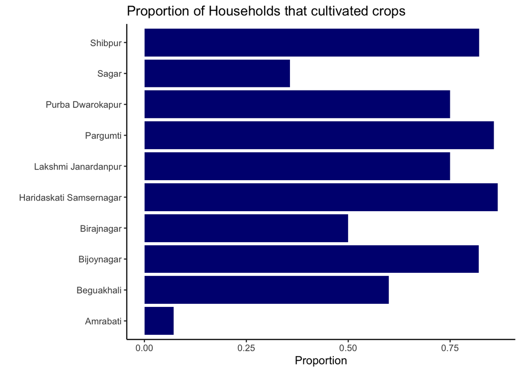

```r
grouped <- baseline %>% group_by(village) %>% summarize(prop_farm = sum(farm_yn)/n())
ggplot(grouped, aes(village,prop_farm)) + geom_col(fill = "navy blue") + labs(x = "", y = "Proportion", title = "Proportion of Households that cultivated crops") + coord_flip() + theme_classic()
```

```r
summary(grouped$prop_farm)
```

```
##    Min. 1st Qu.  Median    Mean 3rd Qu.    Max.
## 0.07143 0.52500 0.75000 0.63938 0.82107 0.86667
```

#What does the data potentially show? *Amrabati by far has the lowest proportion of households that participate in agriculture.* So does this mean that this village has a lower or higher avg household income than the other villages or is the opposite. * What other sources income do they have? * On average, across all the villages, 63.9% of the households participate in farming with the median being 75%. * This is important because almost 3/4 of the households are dependent on farming as a way of life. * Important followup questions can be if education level and working in the farm

## Total Household Income

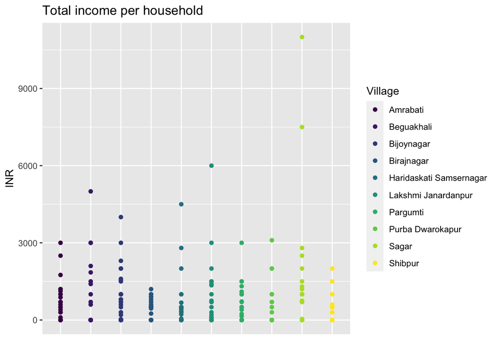

```r
ggplot(baseline, aes(inc_total, village, color = village)) + geom_point() + labs(x = "INR", y = "" ,title = "Total income per household", color = "Village") + coord_flip() + theme(axis.text.x=element_blank(),axis.ticks.x=element_blank()) + scale_color_viridis_d()
```

```r
summary(baseline$inc_total)
```

```
##    Min. 1st Qu.  Median    Mean 3rd Qu.    Max.    NA's
##     0.0     0.0    10.0   606.4   880.0 11000.0       1
```

##Summary of the statistics #From the baseline statistics, the mean total income for all the villages is 606.4 INR #The max total income of a household is 11,000 INR coming from a household in Sagar. # 1 NAs were reported and removed from histogram

#Number of children per household

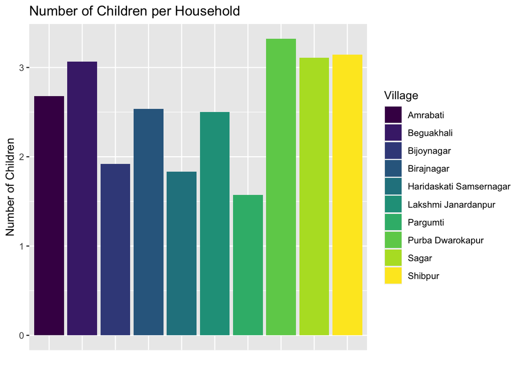

```r
avg_children <- baseline %>% group_by(village) %>% summarize(avg_children = sum(nb_children)/n())

ggplot(avg_children, aes(village, avg_children, fill = village)) + geom_col() + labs(x = "", y = "Number of Children" ,title = "Number of Children per Household", fill = "Village") + theme(axis.text.x=element_blank(),axis.ticks.x=element_blank()) + scale_fill_viridis_d()
```

#Agricultural landholding

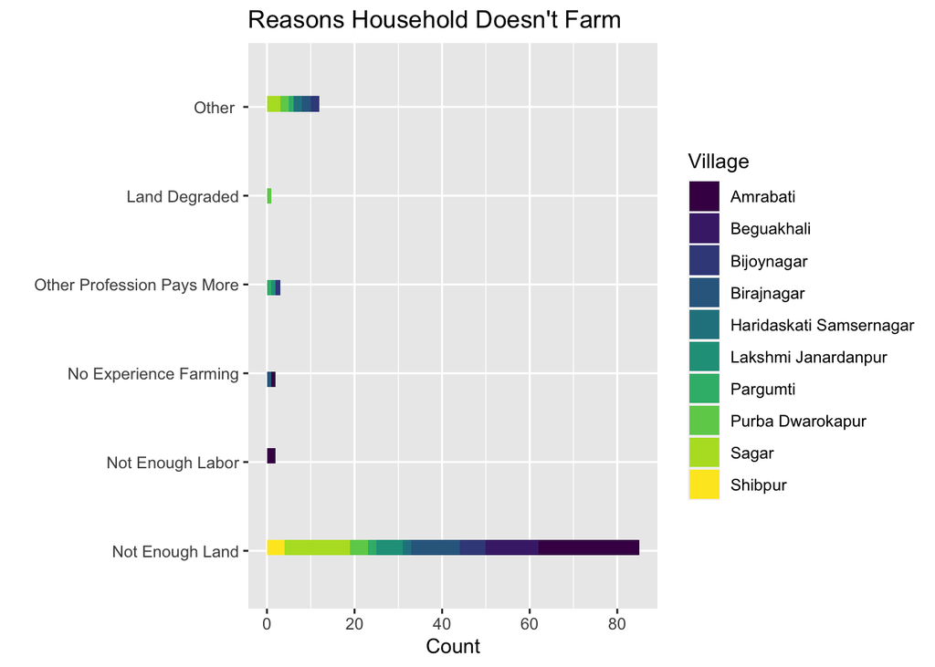

```r
land <- baseline %>% select(village, no_farm_reason) %>% na.omit(no_farm_reason)

land$no_farm_reason <- as.numeric(as.factor(land$no_farm_reason))

ggplot(land, aes(no_farm_reason, fill = village)) + geom_histogram() + labs(x = "", y = "Count" ,title = "Reasons Household Doesn't Farm", fill = "Village") + scale_x_discrete(breaks = c(1,2,3,4,5,6), labels = c("Not Enough Land", "Not Enough Labor", "No Experience Farming", "Other Profession Pays More", "Land Degraded", "Other "), limits = 1:6) + coord_flip() + scale_fill_viridis_d()
```

#What does the data potentially show? This data shows that the biggest reason why a household will not partake in agriculture is because there is not enough land. Land degradation is the lowest reason why the households are not taking part in agriculture. Amrabati specificaly has the most reasons why the households there don’t take part in agriculture, meaning that this issue is more prevalent in that village. Not enough land can mean that either they don’t have access to plots of land to grow crops on or the land itself is not arable.

#Household Assets (by type)

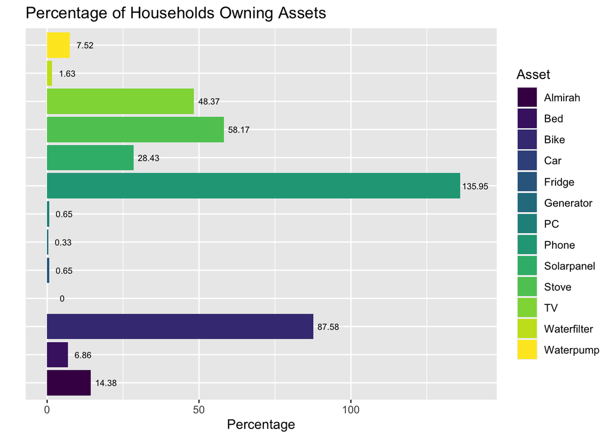

```r
assets <- baseline %>% select(contains("asset")) %>% select(contains("num"))  %>% summarize(Stove = sum(asset_stove_num)/n(), Bike = sum(asset_bike_num)/n(), Car = sum(asset_car_num)/n(), Waterpump = sum(asset_waterpump_num)/n(), Generator = sum(asset_generator_num)/n(), Solarpanel = sum(asset_solarpanel_num)/n(), Bed = sum(asset_bed_num)/n(), Fridge = sum(asset_fridge_num)/n(), Almirah = sum(asset_almirah_num)/n(), PC = sum(asset_pc_num)/n(), TV = sum(asset_tv_num)/n(), Phone = sum(asset_mobile_num)/n(), Waterfilter = sum(asset_waterfilter_num)/n())

assets_long <- gather(assets, property, measurement, Stove:Waterfilter)
assets_long["measurement"] <- assets_long["measurement"]*100
assets_long["measurement"] <- round(assets_long$measurement, digits = 2)

ggplot(assets_long, aes(property, measurement, fill = property)) + geom_col() + labs(x = "", y = "Percentage" ,title = "Percentage of Households Owning Assets", fill  = "Asset") + theme(axis.text.y=element_blank(),axis.ticks.y=element_blank()) + geom_text(aes(label = measurement), size = 2.5, position = position_nudge(y = 5)) + coord_flip() + scale_fill_viridis_d()
```

Important crops

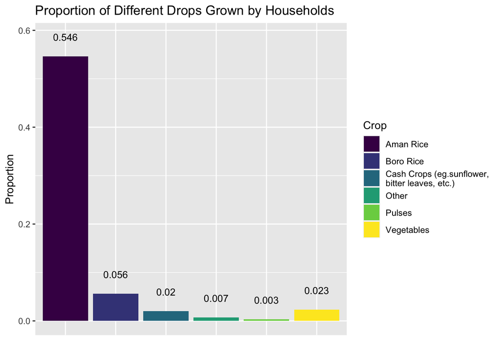

```r
baseline$imp_crop1 <- as.numeric(as.factor(baseline$imp_crop1))

prop_crops1 <- baseline %>% select(village, imp_crop1) %>% filter(imp_crop1 == 1) %>%
  summarize(crop1 = sum(imp_crop1)/count(baseline))
prop_crops2 <- baseline %>% select(village, imp_crop1) %>% filter(imp_crop1 == 2)  %>%
  summarize(crop2 = (sum(imp_crop1)/2)/count(baseline))
prop_crops3 <- baseline %>% select(village, imp_crop1) %>% filter(imp_crop1 == 3) %>%
  summarize(crop2 = (sum(imp_crop1)/3)/count(baseline))
prop_crops4 <- baseline %>% select(village, imp_crop1) %>% filter(imp_crop1 == 4) %>%
  summarize(crop2 = (sum(imp_crop1)/4)/count(baseline))
prop_crops5 <- baseline %>% select(village, imp_crop1) %>% filter(imp_crop1 == 5) %>%
  summarize(crop2 = (sum(imp_crop1)/5)/count(baseline))
prop_crops6 <- baseline %>% select(village, imp_crop1) %>% filter(imp_crop1 == 6) %>%
  summarize(crop2 = (sum(imp_crop1)/6)/count(baseline))

important_crop <- data.frame(c(prop_crops1,prop_crops2,prop_crops3,prop_crops4,prop_crops5,prop_crops6))

important_crop_long <- gather(important_crop, crop, measurement, n:n.5)

important_crop_long$crop <- c("Boro Rice", "Aman Rice", "Vegetables", "Cash Crops (eg.sunflower,
bitter leaves, etc.)", "Pulses", "Other")

important_crop_long["measurement"] <- round(important_crop_long$measurement, digits = 3)

ggplot(important_crop_long, aes(crop, measurement, fill = crop)) + geom_col() + labs(x = "", y = "Proportion" ,title = "Proportion of Different Drops Grown by Households", fill = "Crop") + theme(axis.ticks.x=element_blank(), axis.text.x = element_blank()) + scale_fill_viridis_d() + geom_text(aes(label = measurement), size = 3.5, nudge_y = .04)
```

#What does the data potentially show? Aman rice is the most grown crop by the households. Pulses and other crops are the lowest grown. Monthly Salary

```r
m_salary <-  baseline %>% group_by(village) %>% select(job1_salary1) %>% summarize(avg_salary = sum(job1_salary1, na.rm = TRUE)/n())
```

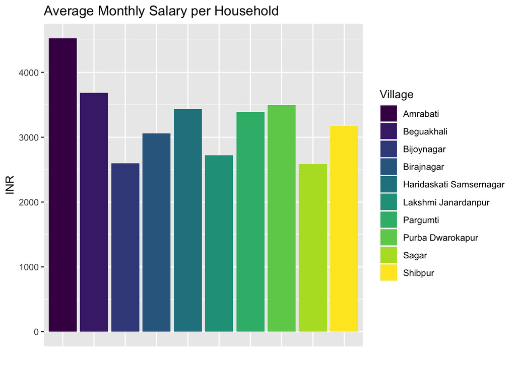

```r
ggplot(m_salary, aes(village, avg_salary, fill = village)) + geom_col() + labs(x = "", y = "INR" ,title = "Average Monthly Salary per Household", fill = "Village") + theme(axis.text.x=element_blank(),axis.ticks.x=element_blank()) + scale_fill_viridis_d()
```

#What does the data potentially show? The data shows that the monthly salaries for the households that receive then range anywhere between 2500 INR to 4600 INR per month. On average, Amrabati receives the highest income and Sagar has the lowest.